# Quality assessment of the HNRNPH1 titration RNA-seq data

Mario Keller

Faculty of Biological Sciences, Goethe University Frankfurt

12 December 2022

```r
library(tidyverse)
library(knitr)
library(ggpubr)
library(ggsci)
library(DESeq2)
library(FactoMineR)
library(factoextra)
```

```r
myTheme <- theme_bw() +
    theme(axis.text = element_text(size = 14, colour="black"),
          axis.title = element_text(size=16, colour="black"),
          axis.ticks=element_line(color="black"),
          axis.ticks.length=unit(.15, "cm"),
          panel.border=element_rect(color="black", fill = NA),
          panel.background = element_blank(),
          plot.background = element_blank(),
          legend.text = element_text(size=12),
          legend.position = "none")
```

```r
projectDir <- "/Users/mariokeller/projects/HNRNPH_project/Tretow_et_al_2023"
datarDir <- paste0(projectDir, "/data")
```

# 1 Background

As an initial step the quality of the RNA-seq data is verified by checking the transcript levels of *HNRNPH1* and *HNRNPH2* as well as of the housekeeping genes *ACTB* and *GAPDH* in the knockdown and overexpression experiments.

In addition, PCAs of the knockdown and overexpression experiments are performed to obtain an overview about individual replicates.

In a final step, *HNRNPH1* transcript and HNRNPH protein levels are correlated to check if both show similar effects in the knockdown and overexpression experiments.

# 2 Data

Dr. Anke Busch from the IMB core facility provided DESeq2 runs of knockdown and overexpression experiments as RData-Files (one for knockdown and one for overexpression). The loaded dds objects are used for the generation of vst-transformed counts and extraction of normalized counts.

As we encountered problems with the third replicate of the two strongest knockdown experiments, these replicates were removed from all analyses.

```r
load(paste0(datarDir, "/DESeq2/DESeq2_knockdown.RData"))

# Rename the dds object
KD_dds <- dds
# Extract normalized counts
KD_counts <- counts(KD_dds, normalized=TRUE)
# vst-transformation
KD_vst <- vst(KD_dds, blind=FALSE)
# Remove unneccessary objects
rm(conts, dds, gtf, pairwise.dds, res, rld, add_factors)


load(paste0(datarDir, "/DESeq2/DESeq2_overexpression.RData"))
# Rename the dds object
OE_dds <- dds
# Extract normalized counts
OE_counts <- counts(OE_dds, normalized=TRUE)
# vst-transformation
OE_vst <- vst(OE_dds, blind=FALSE)
# Remove unneccessary objects
rm(conts, dds, gtf, pairwise.dds, res, rld, add_factors)
```

# 3 Countplots

Countplots for the knockdown and overexpression experiments were generated for *HNRNPH1*, *HNRNPH2*, *ACTB* and *GAPDH* using the normalized counts.

## 3.1 Knockdown experiments

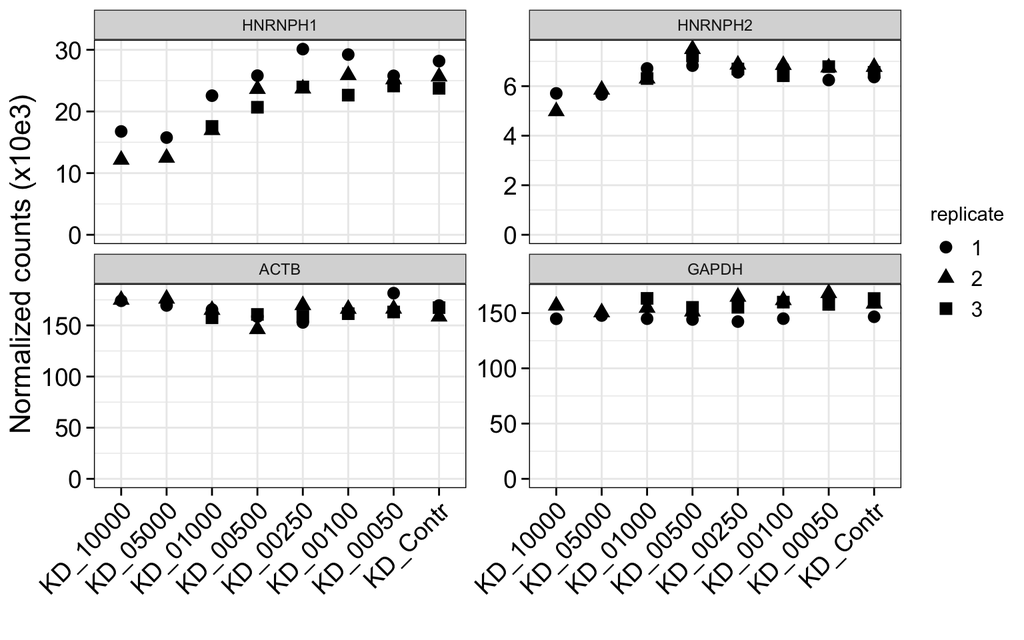

```r
#Set new column names
colnames(KD_counts) <- sapply(c("Contr", "00050", "00100", "00250",
                                "00500", "01000","05000", "10000"),
                              function(exp){paste0("KD_", exp, "_", 1:3)}) %>%
    as.character()

# These are the gene identifiers of the genes of interest
geneIDs <- c(HNRNPH1="ENSG00000169045.17", HNRNPH2="ENSG00000126945.8",
             ACTB="ENSG00000075624.13", GAPDH="ENSG00000111640.14")

# Extract the normalized counts for the four genes and rename the rows
counts <- KD_counts[match(geneIDs, rownames(KD_counts)),]
rownames(counts) <- names(geneIDs)

# Turn the data.frame from a wide into a long format and split the sample info
#   into condition and replicate (e.g. KD_10000_1 => KD_10000 and 1)
counts <- counts %>%
    as.data.frame  %>%
    tibble::rownames_to_column(var="geneName") %>%
    mutate(geneName=factor(geneName, levels=c("HNRNPH1", "HNRNPH2",
                                              "ACTB", "GAPDH"))) %>%
    pivot_longer(., 2:25, names_to = "sample", values_to="normCounts") %>%
    mutate(condition=factor(substr(sample, 1, 8),
                            levels=c("KD_10000", "KD_05000", "KD_01000",
                                     "KD_00500", "KD_00250", "KD_00100",
                                     "KD_00050", "KD_Contr"))) %>%
    mutate(replicate=substr(sample, 10,10))


# Remove the third replicate of the two strongest knockdowns and
#   create the countplot
counts %>% dplyr::filter(!sample %in% c("KD_10000_3", "KD_05000_3")) %>%
ggplot(., aes(x=condition, y=normCounts/1000, shape=replicate)) +
    geom_point(size=3) +
    facet_wrap(~geneName, scales = "free_y") +
    scale_y_continuous(labels = function(x) format(x, big.mark=",",
                                                   scientific=F))  +
    labs(y="Normalized counts (x10e3)", x="") +
    expand_limits(y=0) +
    myTheme +
    theme(axis.text.x = element_text(angle=45, vjust = 1, hjust = 1),
          legend.position = "right")
```

*HNRNPH1* levels shows a strong reduction in the knockdown experiments, while there is only a small reduction of *HNRNPH2* levels and no changes for *ACTB* and *GAPDH*.

## 3.2 Overexpression experiments

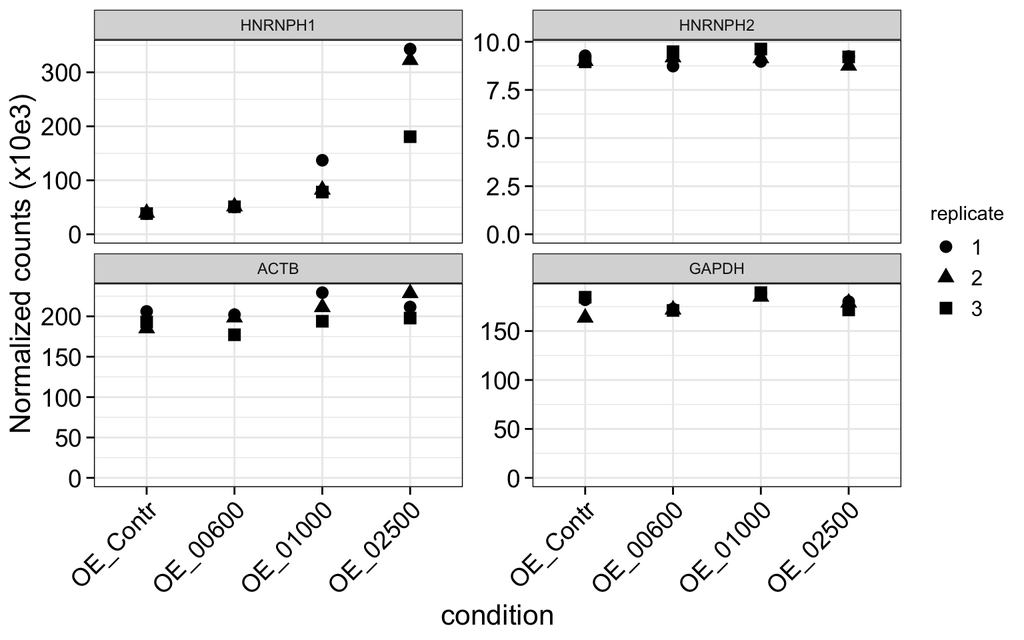

```r
#Set new column names
colnames(OE_counts) <- sapply(1:3, function(rep){paste0("OE_",
                                                        c("Contr", "00600",
                                                          "01000", "02500"),
                                                        "_", rep)}) %>%
    as.character()

# Extract the normalized counts for the four genes and rename the rows
counts <- OE_counts[match(geneIDs, rownames(OE_counts)),]
rownames(counts) <- names(geneIDs)

counts <- counts %>%
    as.data.frame  %>%
    tibble::rownames_to_column(var="geneName") %>%
    mutate(geneName=factor(geneName, levels=c("HNRNPH1", "HNRNPH2",
                                              "ACTB", "GAPDH"))) %>%
    pivot_longer(., 2:13, names_to = "sample", values_to="normCounts") %>%
    mutate(condition=factor(substr(sample, 1, 8),
                            levels=c("OE_Contr", "OE_00600","OE_01000",
                                     "OE_02500", "KD_02500"))) %>%
    mutate(replicate=substr(sample, 10,10))

counts %>%
ggplot(., aes(x=condition, y=normCounts/1000, shape=replicate)) +
    geom_point(size=3) +
    facet_wrap(~geneName, scales = "free_y") +
    scale_y_continuous(labels = function(x) format(x, big.mark=",",
                                                   scientific=F)) +
    labs(y="Normalized counts (x10e3)") +
    expand_limits(y=0) +
    myTheme +
    theme(axis.text.x = element_text(angle=45, vjust = 1, hjust = 1),
          legend.position = "right")
```

*HNRNPH1* levels shows a strong increase in the overexpression experiments, while *HNRNPH2*, *ACTB* and *GAPDH* levels are not affected.

# 4 Priciple Component Analysis

For the principal component analyses we use the vst-transformed counts of the 5.000 genes with the highest variance. For the knockdown and overexpression experiments two separate PCAs are performed.

```r
nGenes <- 5000
```

## 4.1 Knockdown experiments

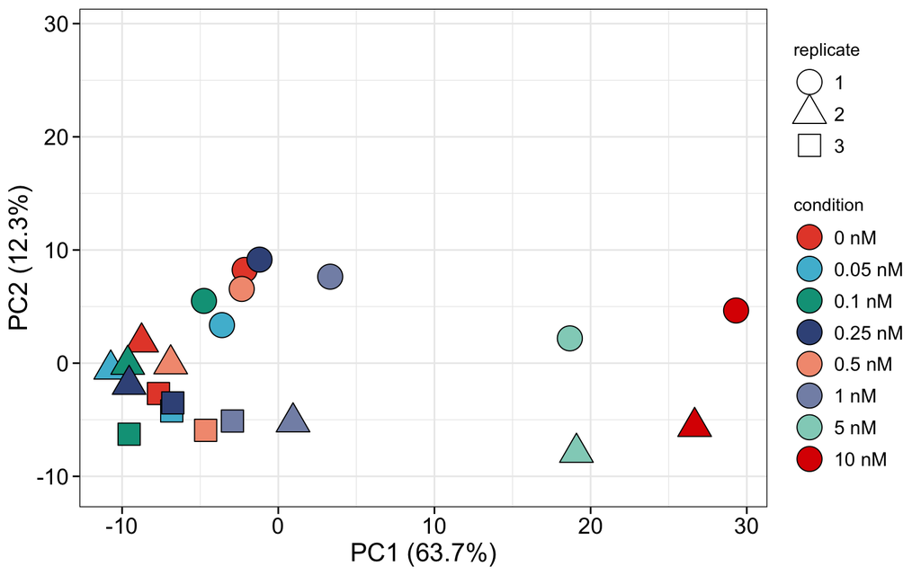

```r
# Set new column names
colnames(KD_vst) <- sapply(c("Contr", "00050", "00100", "00250",
                                "00500", "01000","05000", "10000"),
                              function(exp){paste0("KD_", exp, "_", 1:3)}) %>%
    as.character()

# Extract the vst-transformed counts (except the two third replicates)
KD_matrix <- assay(KD_vst[,-c(21,24)])

# Determine order by decreasing variance
rowOrder <- rowVars(KD_matrix) %>% order(decreasing = T)

# Re-order the matrix
KD_matrix <- KD_matrix[rowOrder,]

# Perform PCA and extract required information
PCAres <- PCA(KD_matrix[1:nGenes,] %>% as.matrix %>% t,  graph = F,
              scale.unit = FALSE)
PCAind <- get_pca_ind(PCAres)
PCAeig <- get_eig(PCAres) %>% round(.,1)

# Generate the data.frame for the PCA plot
PCAdf <- data.frame(PC1=PCAind$coord[,1],
                    PC2=PCAind$coord[,2],
                    PC3=PCAind$coord[,3],
                    condition=factor(rownames(PCAind$coord) %>% substr(., 1, 8),
                                     levels=c("KD_10000", "KD_05000", "KD_01000",
                                     "KD_00500", "KD_00250", "KD_00100",
                                     "KD_00050", "KD_Contr") %>% rev),
                    replicate=factor(rownames(PCAind$coord) %>% substr(., 10, 10),
                                     levels=c(1,2,3)))

# Determine the limits for the plot's x-axis
xylim <- c(
  min(c(PCAdf$PC1, PCAdf$PC2)),
  max(c(PCAdf$PC1, PCAdf$PC2))
)

colNamesKD <- c(KD_10000="10 nM", KD_05000="5 nM", KD_01000="1 nM",
                KD_00500="0.5 nM", KD_00250="0.25 nM", KD_00100="0.1 nM",
                KD_00050="0.05 nM", KD_Contr="0 nM")

ggplot(PCAdf, aes(x=PC1, y=PC2, fill=condition, shape=replicate)) +
    geom_point(size=7) +
    ggsci::scale_fill_npg(labels=colNamesKD) +
    coord_cartesian(xlim=xylim, ylim=xylim) +
    scale_shape_manual(values=c("1" = 21, "2"=24, "3"=22)) +
    scale_x_continuous(n.breaks = 6) +
    scale_y_continuous(n.breaks = 6) +
    labs(x=paste0("PC1 (", PCAeig[1,2], "%)"),
         y=paste0("PC2 (", PCAeig[2,2], "%)")) +
    myTheme +
    theme(legend.position = "right") +
    guides(fill = guide_legend(override.aes=list(shape=21)))
```

PC1 shows a clear separation of the two strongest knockdowns (5 and 10 nM) and to some extent also for the third strongest knockdown (1 nM).

## 4.2 Overexpression experiments

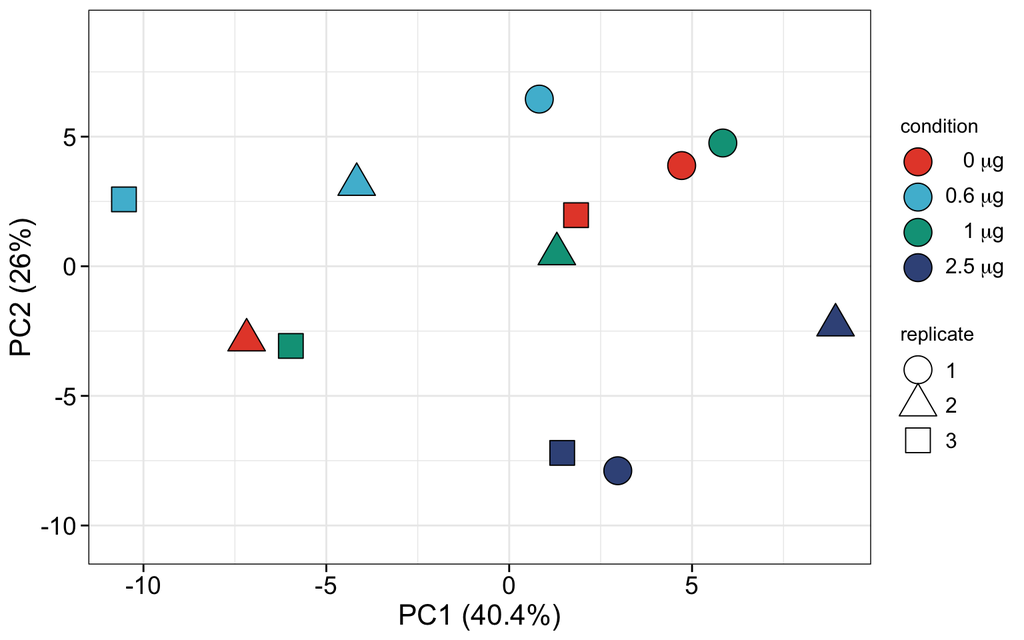

```r
#Set new column names
colnames(OE_vst) <- sapply(1:3, function(rep){paste0("OE_",
                                                     c("Contr", "00600",
                                                       "01000", "02500"),
                                                     "_", rep)}) %>%
    as.character()


# Extract the vst-transformed counts
OE_matrix <- assay(OE_vst)

# Determine order by decreasing variance
rowOrder <- rowVars(OE_matrix) %>% order(decreasing = T)

# Re-order the matrix
OE_matrix <- OE_matrix[rowOrder,]

# Perform PCA and extract required information
PCAres <- PCA(OE_matrix[1:nGenes,] %>% as.matrix %>% t,  graph = F,
              scale.unit = FALSE)
PCAind <- get_pca_ind(PCAres)
PCAeig <- get_eig(PCAres) %>% round(.,1)

# Generate the data.frame for the PCA plot
PCAdf <- data.frame(PC1=PCAind$coord[,1], PC2=PCAind$coord[,2],
                    condition=factor(rownames(PCAind$coord) %>% substr(., 1, 8),
                                     levels=c("OE_Contr", "OE_00600","OE_01000",
                                     "OE_02500", "KD_02500")),
                    replicate=factor(rownames(PCAind$coord) %>% substr(., 10, 10),
                                     levels=c(1,2,3)))

# Determine the limits for the plot's x-axis
xylim <- c(
  min(c(PCAdf$PC1, PCAdf$PC2)),
  max(c(PCAdf$PC1, PCAdf$PC2))
)

colNamesOE <- c(OE_Contr=expression(0~mu*g), OE_00600=expression(0.6~mu*g),
                OE_01000=expression(1~mu*g), OE_02500=expression(2.5~mu*g))

ggplot(PCAdf, aes(x=PC1, y=PC2, fill=condition, shape=replicate)) +
    geom_point(size=7) +
    ggsci::scale_fill_npg(labels=colNamesOE) +
    coord_cartesian(xlim=xylim, ylim=xylim) +
    scale_shape_manual(values=c("1" = 21, "2"=24, "3"=22)) +
    scale_x_continuous(n.breaks = 6) +
    scale_y_continuous(n.breaks = 6) +
    labs(x=paste0("PC1 (", PCAeig[1,2], "%)"),
         y=paste0("PC2 (", PCAeig[2,2], "%)")) +
    myTheme +
    theme(legend.position = "right") +
    guides(fill = guide_legend(override.aes=list(shape=21)))
```

There is not a clear separation visible. The combination of PC1 and PC2 separates the strongest overexpression (2.5 ug) from the other samples.

# 5 Correlation of HNRNPH transcript and protein levels

*HNRNPH1* transcript and HNRNPH protein levels are correlated based on the averaged vst-transformed counts and the relative protein concentration determined by Western blot (relative to the matched Control). For the knockdown and overexpression experiments two separate correlations were performed.

## 5.1 Knockdown experiments

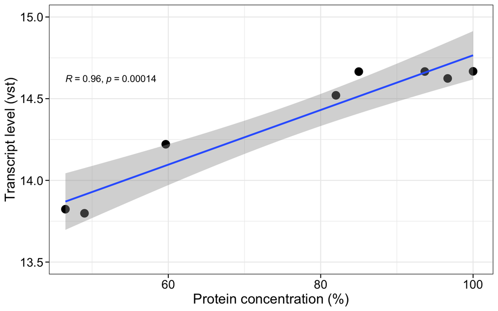

```r
# Average the relative protein concentrations of replicates and set Control
#   to 100%
proteinConc <- c(KD_10000=mean(c(54,39)), KD_05000=mean(c(51,47)),
                   KD_01000=mean(c(54,49,76)), KD_00500=mean(c(80,68,98)),
                   KD_00250=mean(c(84,80,91)), KD_00100=mean(c(102,98,81)),
                   KD_00050=mean(c(95,114,81)), KD_Contr=100)

# Extract the vst-transformed counts of HNRNPH1 and prepare a long data.frame
#   with replicate average vst-transformed counts
vsts <- KD_vst[rownames(KD_vst) == "ENSG00000169045.17",] %>%
    assay %>%
    as.data.frame %>%
    dplyr::select(-c(21,24)) %>% # Removal of the two third replicates
    pivot_longer(., everything(), names_to="condition", values_to="vst") %>%
    mutate(condition=factor(substr(condition, 1, 8),
                            levels=c("KD_10000", "KD_05000", "KD_01000",
                                     "KD_00500", "KD_00250", "KD_00100",
                                     "KD_00050", "KD_Contr"))) %>%
    arrange(condition) %>%
    group_by(condition) %>%
    dplyr::summarise(vst = mean(vst))

# Combine the protein concentrations and vst-transformed counts into a single
#   data.frame
CorrDf <- data.frame(proteinConc = proteinConc, vst = vsts %>% pull(vst))

# Create scatter plot with a regression line and add correlation statistics
ggplot(CorrDf, aes(x=proteinConc, y=vst)) +
    geom_point(size=4) +
    geom_smooth(method = lm) +
    coord_cartesian(ylim=c(13.5,15), xlim=c(47, 100)) +
    stat_cor() +
    labs(x="Protein concentration (%)", y="Transcript level (vst)") +
    myTheme
```

The correlation between the relative protein concentration and the transcript level is very strong (R = 0.96 and p = 0.00014).

## 5.2 Overexpression experiments

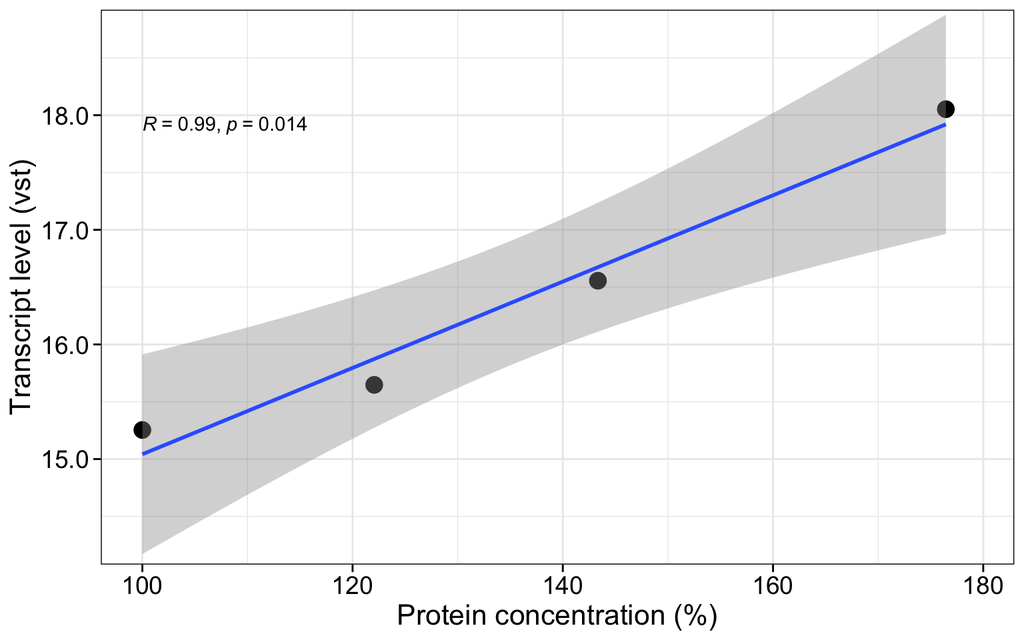

```r
# Average the relative protein concentrations of replicates and set Control
#   to 100%
proteinConc<- c(OE_Contr=100, OE_00600=122.060213917261,
                OE_01000=143.3403293, OE_02500=176.4433966)

# Extract the vst-transformed counts of HNRNPH1 and prepare a long data.frame
#   with replicate average vst-transformed counts
vsts <- OE_vst[rownames(KD_vst) == "ENSG00000169045.17",] %>%
    assay %>%
    as.data.frame %>%
    pivot_longer(., everything(), names_to="cond", values_to="vst") %>%
    mutate(cond=factor(substr(cond, 1, 8), levels=c("OE_Contr", "OE_00600",
                                                    "OE_01000", "OE_02500"))) %>%
    arrange(cond) %>%
    group_by(cond) %>%
    dplyr::summarise(vst = mean(vst))

# Combine the protein concentrations and vst-transformed counts into a single
#   data.frame
CorrDf <- data.frame(proteinConc = proteinConc, vst = vsts %>% pull(vst))

# Create a scatter plot with a regression line and add correlation statistics
ggplot(CorrDf, aes(x=proteinConc, y=vst)) +
    geom_point(size=4) +
    geom_smooth(method = lm) +
    coord_cartesian(ylim=c(14.3, 18.7), xlim=c(100,179)) +
    scale_y_continuous(labels = function(x) paste0(x, ".0"))  +
    stat_cor() +
    labs(x="Protein concentration (%)", y="Transcript level (vst)") +
    myTheme
```

The correlation between the relative protein concentration and the transcript level is very strong (R = 0.99 and p = 0.014).